# Data Science Specialization Capstone Project

Milestone Report

Shaun Wesley Que

# Task 0: Understanding the Problem

In this capstone project, we will be applying data science in the area of natural language processing (NLP). The datasets comes from [HC corpora](http://www.corpora.heliohost.org/), which is a collection of corpora for various languages. The files have been filtered based on languages, but may still contain some foreign text. The dataset can be downloaded from the Coursera Data Science Specialization [Capstone Page](https://d396qusza40orc.cloudfront.net/dsscapstone/dataset/Coursera-SwiftKey.zip).

First, a large corpus of text documents will be analysed to discover the data structure. It will be followed with a series of data processing steps (e.g. removing punctuations, numbers, stopwords, profanities). Next, the datasets will be samples to build a predictive text model. Eventually, a predictive text product will be built.

# Task 1: Data Acquisition and Cleaning

The data are provided in various languages (English, French, German, Finnish) and comes from different data sources (blogs, news, twitter). Only the english context will be analyzed. The list of profanity can be downloaded from this [Free Web Headers Site](http://www.freewebheaders.com/wordpress/wp-content/uploads/full-list-of-bad-words-banned-by-google-txt-file.zip).

```r
setwd("C:/Users/shaun.que/Desktop/DS/Capstone/final/en_US")

# Read datasets
data.blogs   <- read.table("en_US.blogs.txt", header=FALSE, sep="\n",
                           quote="", stringsAsFactors=FALSE)
data.news    <- read.table("en_US.news.txt", header=FALSE, sep="\n",
                           quote="", stringsAsFactors=FALSE)
data.twitter <- read.table("en_US.twitter.txt", header=FALSE, sep="\n",
                           quote="", stringsAsFactors=FALSE)
nrow.data.blogs   <- nrow(data.blogs)
nrow.data.news    <- nrow(data.news)
nrow.data.twitter <- nrow(data.twitter)

data.frame(blogs=nrow.data.blogs, news=nrow.data.news, twitter=nrow.data.twitter, row.names=NULL)
```

```
##    blogs  news twitter
## 1 898384 77258 2302307
```

```r
# Preview datasets
head(data.blogs, n=3)
```

[output not shown]

```r
head(data.news, n=3)
```

```
##                                                                                                                                                                                  V1
## 1                                                                                                                                                 He wasn't home alone, apparently.
## 2                         The St. Louis plant had to close. It would die of old age. Workers had been making cars there since the onset of mass automotive production in the 1920s.
## 3 WSU's plans quickly became a hot topic on local online sites. Though most people applauded plans for the new biomedical center, many deplored the potential loss of the building.
```

```r
head(data.twitter, n=3)
```

```
##                                                                                                                V1
## 1   How are you? Btw thanks for the RT. You gonna be in DC anytime soon? Love to see you. Been way, way too long.
## 2 When you meet someone special... you'll know. Your heart will beat more rapidly and you'll smile for no reason.
## 3                                                                        they've decided its more fun if I don't.
```

```r
# Read profanities
data.profanity <- read.table("en_US.profanity.txt", header=FALSE, sep="\n",
                           quote="", stringsAsFactors=FALSE)
nrow(data.profanity)
```

```
## [1] 550
```

# Task 2: Exploratory Data Analysis

The datasets are analyzed to obtain the general statistics (word counts, line counts). Histograms are plotted for the word counts for the different data sources. It can be seen that blog data have the largest (word count per line) spread . Tweets (Twitter) have much smaller spread.

```r
library(stringi)
library(ggplot2)
```

```r
# Get general text statistics
stri_stats_general(data.blogs$V1)
```

```
##       Lines LinesNEmpty       Chars CharsNWhite
##      898384      898384   207646896   171336847
```

```r
stri_stats_general(data.news$V1)
```

```
##       Lines LinesNEmpty       Chars CharsNWhite
##       77258       77258    15679057    13113058
```

```r
stri_stats_general(data.twitter$V1)
```

```
##       Lines LinesNEmpty       Chars CharsNWhite
##     2302307     2302307   150063800   123870039
```

```r
# Get summary of word counts
counts.blogs <- unlist(stri_count_words(data.blogs$V1))
counts.news <- unlist(stri_count_words(data.news$V1))
counts.twitter <- unlist(stri_count_words(data.twitter$V1))

summary(counts.blogs)
```

```
##    Min. 1st Qu.  Median    Mean 3rd Qu.    Max.
##    0.00    9.00   29.00   42.32   61.00 6726.00
```

```r
summary(counts.news)
```

```
##    Min. 1st Qu.  Median    Mean 3rd Qu.    Max.
##    0.00   19.00   32.00   34.86   46.00 1123.00
```

```r
summary(counts.twitter)
```

```
##    Min. 1st Qu.  Median    Mean 3rd Qu.    Max.
##    0.00    6.00   11.00   12.25   18.00   60.00
```

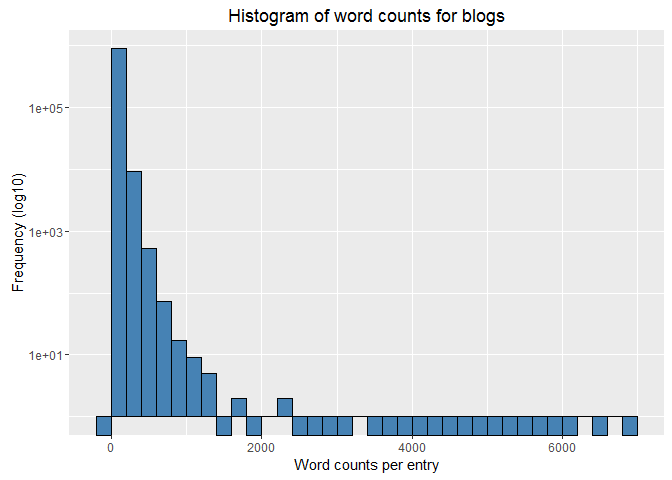

```r
# Plot histograms of word counts
ggplot(as.data.frame(counts.blogs), aes(x=counts.blogs)) +
  geom_histogram(binwidth=200, fill="steelblue", color="black") +
  labs(x="Word counts per entry", y="Frequency (log10)", title="Histogram of word counts for blogs") +
  scale_y_log10()
```

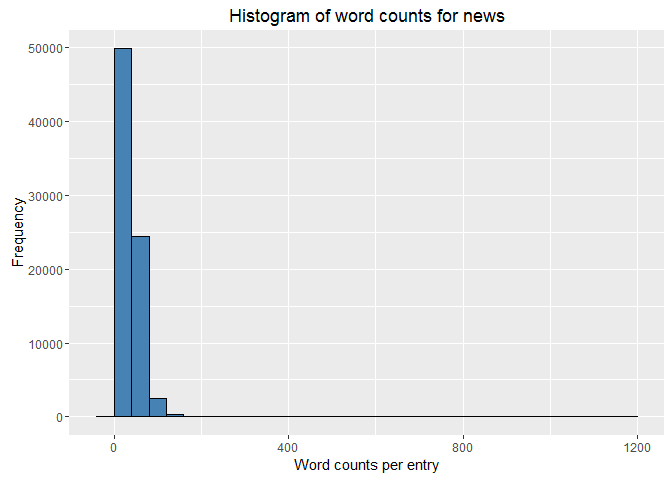

```r
ggplot(as.data.frame(counts.news), aes(x=counts.news)) +
  geom_histogram(binwidth=40, fill="steelblue", color="black") +
  labs(x="Word counts per entry", y="Frequency", title="Histogram of word counts for news")
```

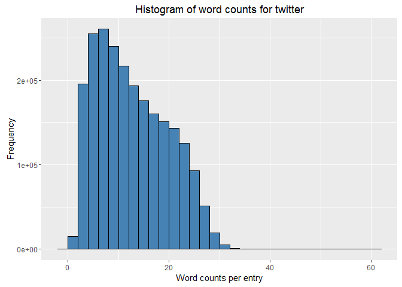

```r
ggplot(as.data.frame(counts.twitter), aes(x=counts.twitter)) +
  geom_histogram(binwidth=2, fill="steelblue", color="black") +
  labs(x="Word counts per entry", y="Frequency", title="Histogram of word counts for twitter")
```

## Data Preprocessing

- removing punctuation
- removing numbers
- removing stop words
- removing profanities
- stemming words
- stripping white space
- converting to lower case

```r
library(data.table)
library(NLP)
library(tm)
library(SnowballC)
```

```r
getCorpus <- function (data, rm_words) {
  #build corpus
  corpus <- Corpus(VectorSource(data))

  # convert words to lower case
  corpus  <- tm_map(corpus, content_transformer(tolower))

  # remove white spaces
  corpus <- tm_map(corpus, stripWhitespace)

  # remove punctuation
  corpus <- tm_map(corpus, removePunctuation)

  # remove numbers
  corpus <- tm_map(corpus, removeNumbers)

  # stem words
  corpus <- tm_map(corpus, stemDocument)

  # remove stopwords
  corpus <- tm_map(corpus, removeWords, rm_words)

  return (corpus)
}

# Set seed
set.seed(323)

sample.pct <- .1
sample.data.blogs <- as.data.frame(data.blogs[sample(nrow.data.blogs, sample.pct * nrow.data.blogs),])
sample.data.news <- as.data.frame(data.blogs[sample(nrow.data.news, sample.pct * nrow.data.news),])
sample.data.twitter <- as.data.frame(data.blogs[sample(nrow.data.twitter, sample.pct * nrow.data.twitter),])

sample.data.blogs[,1] <- as.character(sample.data.blogs[,1])
sample.data.news[,1] <- as.character(sample.data.news[,1])
sample.data.twitter[,1] <- as.character(sample.data.twitter[,1])

nrow.sample.data.blogs <- nrow(sample.data.blogs)
nrow.sample.data.news <- nrow(sample.data.news)
nrow.sample.data.twitter <- nrow(sample.data.twitter)

nrow.data.blogs   <- nrow(data.blogs)
nrow.data.news    <- nrow(data.news)
nrow.data.twitter <- nrow(data.twitter)

data.frame(sample.blogs=nrow.sample.data.blogs,
           sample.news=nrow.sample.data.news,
           sample.twitter=nrow.sample.data.twitter,
           row.names=NULL)
```

```
##   sample.blogs sample.news sample.twitter
## 1        89838        7725         230230
```

```r
corpus.blogs <- getCorpus(sample.data.blogs, c(stopwords('english'), data.profanity$V1))
corpus.news <- getCorpus(sample.data.news, c(stopwords('english'), data.profanity$V1))
corpus.twitter <- getCorpus(sample.data.twitter, c(stopwords('english'), data.profanity$V1))
```

### Tokenization

```r
library(rJava)
library(RWeka)
library(wordcloud)
```

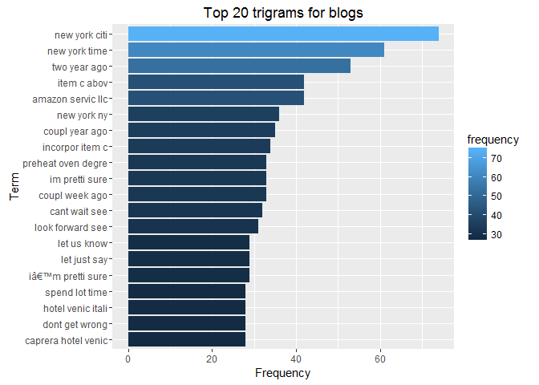

```r
getNGrams <- function(corpus, size, pct) {
  tokenizer <- function(x) NGramTokenizer(x, Weka_control(min = size, max = size))

  tdm <- TermDocumentMatrix(corpus, control = list(tokenize = tokenizer))

  # remove sparse terms
  tdm <- removeSparseTerms(tdm, pct)

  # aggregate term frequencies
  tf <- sort(rowSums(as.matrix(tdm)), decreasing=TRUE)

  return(data.frame(term=names(tf), frequency=tf))
}

# Get unigrams
unigram.blogs <- getNGrams(corpus.blogs, 1, 0.99)
unigram.news <- getNGrams(corpus.news, 1, 0.99)
unigram.twitter <- getNGrams(corpus.twitter, 1, 0.99)

# Get bigrams
bigram.blogs <- getNGrams(corpus.blogs, 2, 0.999)
bigram.news <- getNGrams(corpus.news, 2, 0.999)
bigram.twitter <- getNGrams(corpus.twitter, 2, 0.999)

# Get trigrams
trigram.blogs <- getNGrams(corpus.blogs, 3, 0.9999)
trigram.news <- getNGrams(corpus.news, 3, 0.9999)
trigram.twitter <- getNGrams(corpus.twitter, 3, 0.9999)

# Plot top trigrams
ggplot(trigram.blogs[1:20,], aes(x=reorder(term, frequency), y=frequency, fill=frequency)) + geom_bar(stat="identity") +
  labs(x="Term", y="Frequency", title="Top 20 trigrams for blogs") + coord_flip()
```

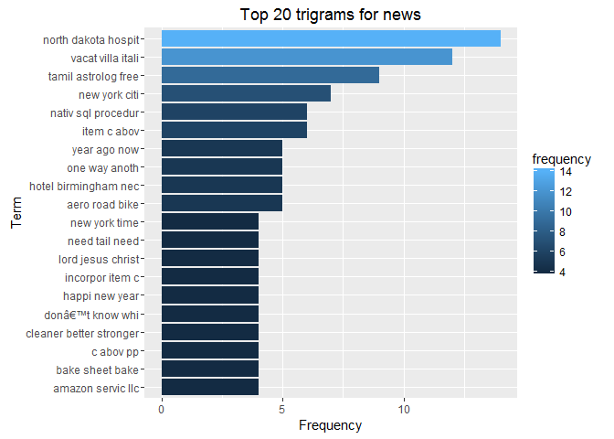

```r
ggplot(trigram.news[1:20,], aes(x=reorder(term, frequency), y=frequency, fill=frequency)) +
    geom_bar(stat="identity") +
    labs(x="Term", y="Frequency", title="Top 20 trigrams for news") + coord_flip()
```

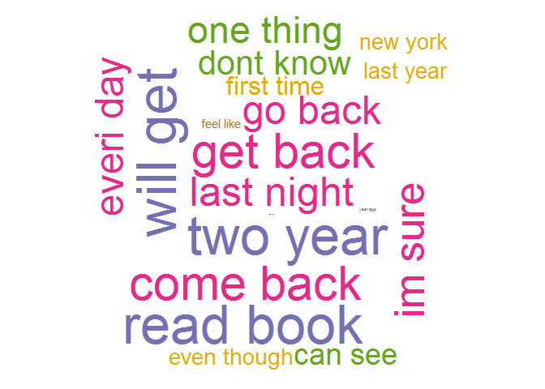

```r
# Plot bigram word clouds
suppressWarnings(wordcloud(bigram.blogs$term, bigram.blogs$frequency, min.freq=5, max.words=50,
                          scale=c(0.1, 6), colors=brewer.pal(8,"Dark2")))
```

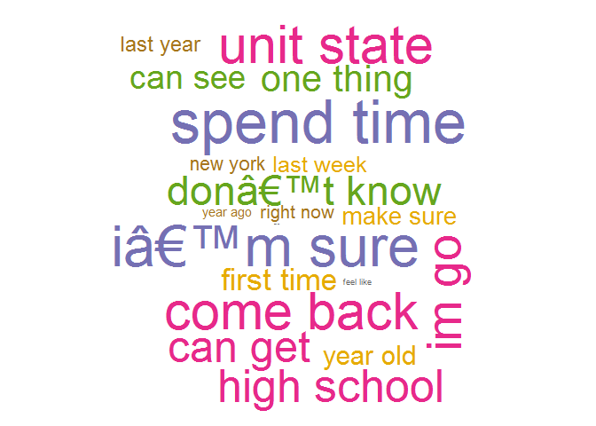

```r
suppressWarnings(wordcloud(bigram.twitter$term, bigram.twitter$frequency, min.freq=5, max.words=50,
                          scale=c(0.1, 6), colors=brewer.pal(10,"Dark2")))
```